# Problem Set 3, due Tuesday, Feb 19th, 11:59pm.

## Introduction to the assignment

For this assignment, you will be using data from the [Progresa program](http://en.wikipedia.org/wiki/Oportunidades), a government social assistance program in Mexico. This program, as well as the details of its impact, are described in the paper "[School subsidies for the poor: evaluating the Mexican Progresa poverty program](http://www.sciencedirect.com/science/article/pii/S0304387803001858)", by Paul Shultz (available on Canvas). The data (progresa_sample.csv.gz) is available on canvas in files/data.

Please read the paper to familiarize yourself with the PROGRESA program before beginning this problem set, so you have a rough sense of where the data come from and how they were generated. If you just proceed into the problem set without understanding Progresa or the data, it will be very difficult!

The goal of this problem set is to implement some of the basic econometric techniques that you are learning in class to measure the impact of Progresa on secondary school enrollment rates, in particular differences-in-differences. Your task is to **estimate the impact of *progresa* subsidies on the school attendance**. Note: this asks to estimate a causal effect.

The timeline of the program was:

- Baseline survey conducted in 1997
- Intervention begins in 1998, "Wave 1" of data collected in 1998
- "Wave 2 of data" collected in 1999
- Evaluation ends in 2000, at which point the control villages were treated.

When you are ready, download the progresa_sample.csv data from Canvas. The data are actual data collected to evaluate the impact of the Progresa program. In this file, each row corresponds to an observation taken for a given child for a given year. There are two years of data (1997 and 1998), and just under 40,000 children who are surveyed in both years. For each child-year observation, the following variables are collected:

| Variable name | Description |
| --- | --- |
| year | year in which data is collected |
| sex | male = 1 |
| indig | indigenous = 1 |
| dist_sec | nearest distance to a secondary school |
| sc | enrolled in school in year of survey (=1) |
| grc | grade enrolled |
| fam_n | family size |
| min_dist | min distance to an urban center |
| dist_cap | min distance to the capital |
| poor | poor = "pobre", not poor = "no pobre" |
| progresa | treatment = "basal", control = "0" |
| hohedu | years of schooling of head of household |
| hohwag | monthly wages of head of household |
| welfare_index | welfare index used to classify poor |
| hohsex | gender of head of household (male=1) |
| hohage | age of head of household |
| age | years old |
| folnum | individual id |
| village | village id |
| sc97 | enrolled in school in 1997 (=1) |

## Part 1: Descriptive analysis

### 1.1 Summary Statistics

Report summary statistics (mean, standard deviation, and number of missings) for all of the demographic variables in the dataset (i.e., everything except year, folnum, village). A central variable, *progresa* is coded in a rather unintuitive way. Find it's actual coding scheme (levels). Does this fit with the documentation above?

Present these in a single table alphabetized by variable name. Do NOT simply expect the grader to scroll through your output!

```python
# Required libraries
import pandas as pd
import numpy as np
import scipy.stats as sp
import seaborn as sns
import matplotlib.pyplot as plt
import statsmodels.formula.api as smf
```

```python
#Read the data
progresa_df = pd.read_csv('progresa_sample.csv.gz')

## Encoding the poor and progresa columns to numeric
progresa_df['poor'] = progresa_df['poor'].map({'pobre': 1, 'no pobre': 0})
progresa_df['progresa'] = progresa_df['progresa'].map({'basal' : 1, '0':0})

## Remove the columns year, folnum and village
progresa_df_new = progresa_df.drop(['year','folnum','village'], axis=1)

## Number of missing values
missing_vals_count = list(progresa_df_new.isnull().sum().sort_index())

## Calculate the mean and standard deviation
summary_table = progresa_df_new.describe().loc[['mean','std']].transpose().sort_index()
summary_table['No_of_missing_vals'] = missing_vals_count
summary_table
```

[output not shown]

##### The progresa column has 2 values, basal and 0. Basal represents if the corresponding row of data is in treatment or control group. It is encoded as 1 and 0 for treatment and control group respectively.

### 1.2 Differences at baseline?

Now let's investigate the differences in baseline. Are the baseline (1997) demographic characteristics **for the poor** different in treatment and control villages?

I suggest you to use a T-Test to determine whether there is a statistically significant difference in the average values of each of the variables in the dataset. Focus only on the data from 1997 for poor.

Present your results in a single table with the following columns and 14 (or so) rows:

| Variable name | Average value (Treatment villages) | Average value (Control villages) | Difference (Treat - Control) | p-value |
| --- | --- | --- | --- | --- |
| Male | ? | ? | ? | ? |

```python
#Split the dataframe as treatment and control groups with selecting only the poor for year 1997
treatment_df = progresa_df[(progresa_df.progresa == 1) & (progresa_df.year == 97) & (progresa_df.poor == 1)]
control_df = progresa_df[(progresa_df.progresa == 0) & (progresa_df.year == 97) & (progresa_df.poor == 1)]

#Mean for treatment group villages
treatment_df = treatment_df[treat_df.columns.difference(['year','folnum','village', 'poor', 'progresa'])].fillna(0)
treatment_mean_df = treatment_df.describe().loc['mean']
treatment_mean_df = pd.DataFrame({'Variable name':treatment_mean_df.index,
                                  'Average Value(Treatment villages)':treatment_mean_df.values},
                                  columns = ['Variable name', 'Average Value(Treatment villages)'])

#Mean for control group villages
control_df = control_df[control_df.columns.difference(['year','folnum','village', 'poor', 'progresa'])].fillna(0)
control_mean_df = control_df.describe().loc['mean']
control_mean_df = pd.DataFrame({'Variable name':control_mean_df.index,
                                  'Average Value(Control villages)':control_mean_df.values},
                                  columns = ['Variable name', 'Average Value(Control villages)'])

#Merge the dataframes
mean_df_poor_97 = pd.merge(treatment_mean_df, control_mean_df, on = 'Variable name')

pVal_list = {}
tval_list = {}
varNames_list = list(treatment_df)

#Run t-test to get the p-values
for x in range(0, len(mean_df_poor_97)):
    pVal_list.update({varNames_list[x]: sp.ttest_ind(treatment_df.transpose().iloc[x], control_df.transpose().iloc[x]).pvalue})
    tval_list.update({varNames_list[x]: sp.ttest_ind(treatment_df.transpose().iloc[x], control_df.transpose().iloc[x]).statistic})

pVal_df = pd.DataFrame(list(pVal_list.items()), columns = ['Variable name', 'p-value'])
tval_df = pd.DataFrame(list(tval_list.items()), columns = ['Variable name', 'Difference (Treat - Control)'])

mean_df_poor_97 = pd.merge(mean_df_poor_97, tval_df, on = 'Variable name')
mean_df_poor_97 = pd.merge(mean_df_poor_97, pVal_df, on = 'Variable name')
mean_df_poor_97
```

|  | Variable name | Average Value(Treatment villages) | Average Value(Control villages) | Difference (Treat - Control) | p-value |
| --- | --- | --- | --- | --- | --- |
| 0 | age | 10.716991 | 10.742023 | -0.708630 | 4.785594e-01 |
| 1 | dist_cap | 150.829074 | 153.769730 | -3.339081 | 8.415005e-04 |
| 2 | dist_sec | 2.453122 | 2.507662 | -2.100433 | 3.569843e-02 |
| 3 | fam_n | 7.281327 | 7.302469 | -0.794167 | 4.271039e-01 |
| 4 | grc | 3.531599 | 3.543050 | -0.400196 | 6.890151e-01 |
| 5 | grc97 | 3.531599 | 3.543050 | -0.400196 | 6.890151e-01 |
| 6 | hohage | 43.640194 | 44.273369 | -4.810013 | 1.515918e-06 |
| 7 | hohedu | 2.663139 | 2.590348 | 2.541229 | 1.105093e-02 |
| 8 | hohsex | 0.924290 | 0.922799 | 0.493343 | 6.217737e-01 |
| 9 | hohwag | 544.339544 | 573.163558 | -3.594588 | 3.253835e-04 |
| 10 | indig | 0.324696 | 0.331169 | -1.211794 | 2.255999e-01 |
| 11 | min_dist | 107.152915 | 103.237854 | 8.206584 | 2.358312e-16 |
| 12 | sc | 0.779003 | 0.769440 | 2.012611 | 4.416380e-02 |
| 13 | sc97 | 0.779003 | 0.769440 | 2.012611 | 4.416380e-02 |
| 14 | sex | 0.519138 | 0.504890 | 2.503945 | 1.228655e-02 |
| 15 | welfare_index | 655.136672 | 655.772006 | -0.470581 | 6.379435e-01 |

### 1.3 Interpretation

- A: Are there statistically significant differences between treatment and control villages as baseline?
- B: Why does it matter if there are differences at baseline?
- C: What does this imply about how to measure the impact of the treatment?

**B: Why does it matter if there are differences at baseline?**  
When randomly selecting two groups for comparison, they should be similar in order to compare the differences after applying a particular treatment. But if there is difference in Baseline, it tells us that the samples, we selected for Treatment and Control were not similar i.e., they are statistically different from each other. The basis of applying a Treatment and control strategy is to observe the effect of a particular treatment on a group of individuals vs those who did not receive the treatment. Thus it is essential to start at an indistinguishable baseline in order to record accurate causal analysis and observe genuine patterns.

**C: What does this imply about how to measure the impact of the treatment?**  
*As there is significant difference between several variables of treatment and control groups prior to the treatment, the impact measured using this sample might not show the true impact. Thus we should use a different strategy like stratified sampling or double differences to randomise the sample to derive any causal effect.*

### 1.4 Graphical exploration, part 1

For each level of household head education, compute the average enrollment rate in 1997. Create a scatterplot that shows this relationship. What do you notice?

```python
# Calculate the enrollment rate.
enroll_rate = pd.DataFrame(progresa_df[(progresa_df.year == 97)].groupby('hohedu').mean()['sc']).reset_index()
enroll_rate.columns = ['Hohedu', 'Enrollment_Rate']
count_rate = pd.DataFrame(progresa_df[(progresa_df.year == 97)].groupby('hohedu').count()['sc']).reset_index()
count_rate.columns = ['Hohedu', 'Count']
hohedu_enroll_count_df = pd.merge(enroll_rate, count_rate, on = 'Hohedu')
hohedu_enroll_count_df
```

|  | Hohedu | Enrollment_Rate | Count |
| --- | --- | --- | --- |
| 0 | 0 | 0.776137 | 9957 |
| 1 | 1 | 0.768537 | 2549 |
| 2 | 2 | 0.794552 | 5617 |
| 3 | 3 | 0.802956 | 7374 |
| 4 | 4 | 0.842951 | 2738 |
| 5 | 5 | 0.849835 | 1212 |
| 6 | 6 | 0.878469 | 5225 |
| 7 | 7 | 0.889535 | 172 |
| 8 | 8 | 0.900000 | 290 |
| 9 | 9 | 0.925023 | 1067 |
| 10 | 10 | 0.865385 | 52 |
| 11 | 11 | 0.974359 | 39 |
| 12 | 12 | 0.982955 | 176 |
| 13 | 13 | 0.959459 | 74 |
| 14 | 14 | 0.880952 | 42 |
| 15 | 15 | 0.900000 | 30 |
| 16 | 16 | 0.941176 | 34 |
| 17 | 17 | 0.933333 | 15 |
| 18 | 18 | 1.000000 | 24 |
| 19 | 20 | 0.500000 | 2 |

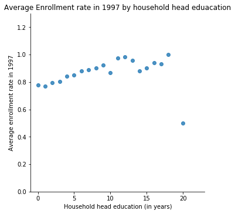

```python
#Scatterplot of departure delay for different months and origins
sns.lmplot(x = 'Hohedu', y = 'Enrollment_Rate', data = enroll_rate, fit_reg=False)
plt.xlim(-1, 23)
plt.ylim(0, 1.3)
plt.title('Average Enrollment rate in 1997 by household head eduacation')
plt.xlabel('Household head education (in years)')
plt.ylabel('Average enrollment rate in 1997')
plt.show()
```

##### From the above graph, we could see that as the years of household head's education increases, the average enrollment rate of their children to school also increases. But there is a slight fluctuation in the enrollment rate in the higher range of household head's education. Also we could see a drastic drop at the point where the household head education is around 20 years, the average enrollment is in its minimum value. This could be possible due to a very low number of datapoints(2).

### 1.5 Graphical exploration, part 2

1. On each histogram, draw a vertical line that intersects the x-axis at the average value (across all households). Does there appear to be a difference? Is this difference statistically significant?

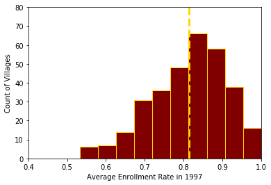

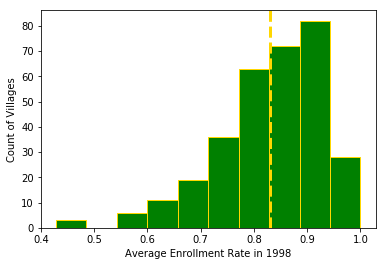

```
Mean of Enrollment Rate in 1997:  0.8138394110596501
Mean of Enrollment Rate in 1998:  0.8295362042630732
```

```python
# Filter only the poor treated villages for both years
treated_poor_97 = progresa_df[(progresa_df.poor == 1) & (progresa_df.year == 97) & (progresa_df.progresa == 1)]
treated_poor_98 = progresa_df[(progresa_df.poor == 1) & (progresa_df.year == 98) & (progresa_df.progresa == 1)]

#Calculate the average enrollment rate
enroll_rate_97_df = treated_poor_97.groupby([treated_poor_97.village])['sc'].mean().reset_index(name = 'Avg_Enrollment_Rate_97')
enroll_rate_98_df = treated_poor_98.groupby([treated_poor_98.village])['sc'].mean().reset_index(name = 'Avg_Enrollment_Rate_98')

# Histogram before the Treatment - 1997
fig = plt.figure()
ax1 = plt.hist(enroll_rate_97_df['Avg_Enrollment_Rate_97'], color = "maroon", edgecolor='gold')
plt.xlabel("Average Enrollment Rate in 1997")
plt.ylabel("Count of Villages")
plt.ylim([0,80])
plt.xlim([0.4,1.0])
plt.axvline(enroll_rate_97_df['Avg_Enrollment_Rate_97'].mean(), color='gold', linestyle='dashed', linewidth=3)
plt.show()

# Histogram after the Treatment - 1998
fig = plt.figure()
ax2 = plt.hist(enroll_rate_98_df['Avg_Enrollment_Rate_98'], color = "green", edgecolor='gold')
plt.xlabel("Average Enrollment Rate in 1998")
plt.ylabel("Count of Villages")
plt.axvline(enroll_rate_98_df['Avg_Enrollment_Rate_98'].mean(), color='gold', linestyle='dashed', linewidth=3)
plt.show()

#Printing the average values
print ('Mean of Enrollment Rate in 1997: ', enroll_rate_97_df['Avg_Enrollment_Rate_97'].mean())
print ('Mean of Enrollment Rate in 1998: ', enroll_rate_98_df['Avg_Enrollment_Rate_98'].mean())
```

## Part 2: Measuring Impact

Our goal is to estimate the causal impact of the PROGRESA program on the social and economic outcomes of individuals in Mexico. We will focus on the impact of the program on the poor (those with poor=='pobre'), since only the poor were eligible to receive the PROGRESA assistance.

### 2.1 Cross-Sectional Estimator: T-test

Begin by estimating the impact of Progresa using "simple differences." Restricting yourself to data from 1998 (after treatment), calculate the average enrollment rate among **poor** households in the Treatment villages and the average enrollment rate among **poor** households in the control villages. Use a t-test to determine if this difference is statistically significant. What do you conclude?

```python
# Filter the poor control and treatment villages for year 1998
treatment_df_98 = progresa_df[(progresa_df.progresa == 1) & (progresa_df.year == 98) & (progresa_df.poor == 1)]
control_df_98 = progresa_df[(progresa_df.progresa == 0) & (progresa_df.year == 98) & (progresa_df.poor == 1)]

# Calculate the mean
print('The average enrollment rate among poor treatment villages for the year 1998: ', treatment_df_98.mean()['sc'])
print('The average enrollment rate among poor control villages for the year 1998: ', control_df_98.mean()['sc'])

print('t-value: ', sp.ttest_ind(treatment_df_98['sc'], control_df_98['sc'], nan_policy = 'omit').statistic)
print('p-value: ', sp.ttest_ind(treatment_df_98['sc'], control_df_98['sc'], nan_policy = 'omit').pvalue)
```

```
The average enrollment rate among poor treatment villages for the year 1998:  0.846479121395
The average enrollment rate among poor control villages for the year 1998:  0.80763695673
t-value:  8.35872056742
p-value:  6.63634444738e-17
```

### 2.2 Cross-Sectional Estimator: Regression

Estimate the effects of Progresa on enrollment using a regression model, by regressing the 1998 enrollment rates **of the poor** on treatment assignment. Do not include any additional control variables. Discuss the following:

- Based on this model, how much did Progresa increase the likelihood of a child enrolling?
- How does your regression estimate compare to your t-test estimate from part 2.1?
- Based on this regression model, can we reject the null hypothesis that the treatment effects are zero?
- What is the counterfactual assumption underlying this regression?

Note: I recommend to use statsmodels.formula.api as this allows to use convenient R-style formulas and provedes nice summaries of the results.

```python
# filter only the poor for year 1998
poor_98_df = progresa_df[(progresa_df.poor == 1) & (progresa_df.year == 98)]

# Linear model
lm_poor_98 = smf.ols(formula = 'sc ~ progresa', data = poor_98_df).fit()
lm_poor_98.summary()
```

OLS Regression Results

| Dep. Variable: | sc | R-squared: | 0.003 |
| --- | --- | --- | --- |
| Model: | OLS | Adj. R-squared: | 0.003 |
| Method: | Least Squares | F-statistic: | 69.87 |
| Date: | Tue, 19 Feb 2019 | Prob (F-statistic): | 6.64e-17 |
| Time: | 01:20:30 | Log-Likelihood: | -11926. |
| No. Observations: | 27450 | AIC: | 2.386e+04 |
| Df Residuals: | 27448 | BIC: | 2.387e+04 |
| Df Model: | 1 |  |  |
| Covariance Type: | nonrobust |  |  |

|  | coef | std err | t | P>\|t\| | [0.025 | 0.975] |
| --- | --- | --- | --- | --- | --- | --- |
| Intercept | 0.8076 | 0.004 | 220.676 | 0.000 | 0.800 | 0.815 |
| progresa | 0.0388 | 0.005 | 8.359 | 0.000 | 0.030 | 0.048 |

| Omnibus: | 7638.939 | Durbin-Watson: | 1.734 |
| --- | --- | --- | --- |
| Prob(Omnibus): | 0.000 | Jarque-Bera (JB): | 15767.534 |
| Skew: | -1.767 | Prob(JB): | 0.00 |
| Kurtosis: | 4.140 | Cond. No. | 3.01 |

**Based on this model, how much did Progresa increase the likelihood of a child enrolling?**  
*We could see that the coefficient value for the progresa is positive, hence progresa increases the likelihood of a child to be enrolled in school. The value of this coefficient is 0.0388 and the intercept is 0.8076. Therefore Progresa increases the likelihood of enrollment by 0.0388 i.e. likelihood of enrollment without progresa is 0.8076 and with progresa is 0.8464(0.8076 + 0.0388)*

**How does your regression estimate compare to your t-test estimate from part 2.1?**  
*The values from the regression model confirms the values from the t-test. Average enrollment rate for the control villages from the t-test is 0.80 which is the same as the value of intercept from the linear regression(without treatment). Similarly the average enrollment rate for treatment villages from the t-test is 0.84 and is same as the value from the regression model(0.8076 + 0.0388 = 0.8464)*

**What is the counterfactual assumption underlying this regression?**  
*The counterfactual assumption underlying this regression is that if there was no treatment, there would not be any change observed i.e, the average enrollment rate for treated and control villages would have remained the same.*

### 2.3 Multiple Regression

Re-run the above regression estimated but this time include a set of relevant control variables. Include, for instance, age, distance to a secondary school, gender, education of household head, welfare index, indigenous, etc.

- How do the controls affect the point estimate of treatment effect?
- How do the controls affect the standard error on the treatment effect?
- How do you interpret the differences (or similarities) between your estimates of 2.2 and 2.3?

```python
# Multiple linear regression model
lm_poor_98_multiple = smf.ols(formula = 'sc ~ age + progresa + indig + dist_sec + sex + hohedu + welfare_index + fam_n + hohwag + hohsex + hohage',
                              data = poor_98_df).fit()

lm_poor_98_multiple.summary()
```

OLS Regression Results

| Dep. Variable: | sc | R-squared: | 0.267 |
| --- | --- | --- | --- |
| Model: | OLS | Adj. R-squared: | 0.267 |
| Method: | Least Squares | F-statistic: | 903.0 |
| Date: | Tue, 19 Feb 2019 | Prob (F-statistic): | 0.00 |
| Time: | 01:47:43 | Log-Likelihood: | -7634.1 |
| No. Observations: | 27260 | AIC: | 1.529e+04 |
| Df Residuals: | 27248 | BIC: | 1.539e+04 |
| Df Model: | 11 |  |  |
| Covariance Type: | nonrobust |  |  |

|  | coef | std err | t | P>\|t\| | [0.025 | 0.975] |
| --- | --- | --- | --- | --- | --- | --- |
| Intercept | 1.4868 | 0.019 | 79.742 | 0.000 | 1.450 | 1.523 |
| age | -0.0656 | 0.001 | -94.281 | 0.000 | -0.067 | -0.064 |
| progresa | 0.0353 | 0.004 | 8.804 | 0.000 | 0.027 | 0.043 |
| indig | 0.0464 | 0.004 | 11.115 | 0.000 | 0.038 | 0.055 |
| dist_sec | -0.0117 | 0.001 | -13.240 | 0.000 | -0.013 | -0.010 |
| sex | 0.0309 | 0.004 | 7.957 | 0.000 | 0.023 | 0.039 |
| hohedu | 0.0088 | 0.001 | 10.328 | 0.000 | 0.007 | 0.011 |
| welfare_index | 2.8e-05 | 1.83e-05 | 1.532 | 0.126 | -7.83e-06 | 6.38e-05 |
| fam_n | -0.0003 | 0.001 | -0.381 | 0.703 | -0.002 | 0.001 |
| hohwag | -1.111e-06 | 2.84e-06 | -0.392 | 0.695 | -6.67e-06 | 4.45e-06 |
| hohsex | 0.0124 | 0.008 | 1.592 | 0.111 | -0.003 | 0.028 |
| hohage | 0.0002 | 0.000 | 1.193 | 0.233 | -0.000 | 0.001 |

| Omnibus: | 2993.509 | Durbin-Watson: | 1.718 |
| --- | --- | --- | --- |
| Prob(Omnibus): | 0.000 | Jarque-Bera (JB): | 4084.933 |
| Skew: | -0.940 | Prob(JB): | 0.00 |
| Kurtosis: | 3.248 | Cond. No. | 9.95e+03 |

**How do the controls affect the point estimate of treatment effect?**  
*After the addition of more control variables, we could see that the coefficient value of progresa variable for the treatment effect, has decreased to 0.0353 from the single-linear regression model value of 0.0388 with a significant p-value. We can also observe that there are other parameters which exhibit statistically significant effect on the average enrollment rate. The intercept value has also increased significantly.*

**How do the controls affect the standard error on the treatment effect?**  
*After adding the control variables, the standard error for the progresa variable has reduced from 0.005 to 0.004. Thus we can conlcude that addition of more control variables has improved the model accuracy.*

**How do you interpret the differences (or similarities) between your estimates of 2.2 and 2.3?**  
*We could see that the progresa coefficient has decreased a little, and intercept value has increased considerably. The inclusion of more control variables did affect the model significantly. In case of multiple regression, standard error is lower and hence the model accuracy is improved, making it a better model for the given data.*

### 2.4 Difference-in-Difference, version 1 (tabular)

Thus far, we have computed the effects of Progresa by estimating the difference in 1998 enrollment rates across villages. An alternative approach would be to compute the treatment effect using a difference-in-differences framework.

Begin by estimating the average treatment effects of the program for poor households using data from 1997 and 1998. Specifically, calculate:

a) the difference (between 1997 and 1998) in enrollment rates among poor households in treated villages

b) the difference (between 1997 and 1998) in enrollment rates among poor households in control villages.

c) The difference between these two differences is your estimate.

- What is your estimate of the impact, and how does it compare to your earlier (simple difference) results?
- What is the counterfactual assumption underlying this estimate?

```python
#Filter the poor treated villages for 1997 and 1998
treatment_df_97 = progresa_df[(progresa_df.progresa == 1) & (progresa_df.year == 97) & (progresa_df.poor == 1)]
treatment_df_98 = progresa_df[(progresa_df.progresa == 1) & (progresa_df.year == 98) & (progresa_df.poor == 1)]


print('Difference in the enrollment rate between 1997 and 1998 for treatment villages: ',
      treatment_df_98.mean()['sc'] - treatment_df_98.mean()['sc'])

#Filter the poor control villages for 1997 and 1998
control_df_97 = progresa_df[(progresa_df.progresa == 0) & (progresa_df.year == 97) & (progresa_df.poor == 1)]
control_df_98 = progresa_df[(progresa_df.progresa == 0) & (progresa_df.year == 98) & (progresa_df.poor == 1)]


## Create a datframe for tabular representation
diffInDiff_df = pd.DataFrame(index = ['Control', 'Treatment'],
                             columns = ['Avg enrollment rate - 1997', 'Avg enrollment rate - 1998', 'Difference'])
diffInDiff_df.loc['Control', 'Avg enrollment rate - 1997'] = control_df_97.mean()['sc']
diffInDiff_df.loc['Control', 'Avg enrollment rate - 1998'] = control_df_98.mean()['sc']
diffInDiff_df.loc['Treatment', 'Avg enrollment rate - 1997'] = treatment_df_97.mean()['sc']
diffInDiff_df.loc['Treatment', 'Avg enrollment rate - 1998'] = treatment_df_98.mean()['sc']
diffInDiff_df['Difference'] = diffInDiff_df['Avg enrollment rate - 1998'] - diffInDiff_df['Avg enrollment rate - 1997']
diffInDiff_df
```

[output not shown]

|  | Avg enrollment rate - 1997 | Avg enrollment rate - 1998 | Difference |
| --- | --- | --- | --- |
| Control | 0.815186 | 0.807637 | -0.00754905 |
| Treatment | 0.822697 | 0.846479 | 0.0237822 |

```python
#Calculating difference of difference
diff = diffInDiff_df.loc['Treatment', 'Difference'] - diffInDiff_df.loc['Control', 'Difference']
print ('The difference of difference in the average enrollment rate is: ', diff)
```

```
The difference of difference in the average enrollment rate is:  0.0313312803193
```

**What is your estimate of the impact, and how does it compare to your earlier (simple difference) results?**  
_The estimate of the impact is found to be 0.0313 which is lesser than the estimates from simple linear regression(0.0388) and multiple linear regression(0.0353). This increase in the enrollment rate can be completely conformed as the effect of progresa treatment. Also, as the multiple linear regression estimate had a better std. error, we can say that the diff-in-diff estimate is more accurate.

**What is the counterfactual assumption underlying this estimate?**  
The counterfactual assumption would be that we might have achieved the same difference in average enrollment rate between treatment group and control group irrespective of the treatment.

### 2.5 Difference-in-Difference, version 2 (regression)

Now use a regression specification to estimate the average treatment effects of the program in a difference-in-differences framework. Include at least 5 control variables.

- What is your estimate of the impact of Progresa? Be very specific in interpreting your coefficients and standard errors, and make sure to specify exactly what units you are measuring and estimating.
- How do these estimates of the treatment effect compare to the estimates based on the simple difference?
- How do these estimates compare to the difference-in-difference estimates from 2.4 above? What accounts for these differences?
- What is the counterfactual assumption underlying this regression?

```python
#Filter only the poor
progresa_df_poor = progresa_df[progresa_df.poor == 1]

#Create a binary variable to code for the treatment before and after
progresa_df_poor['after_treat'] = np.where(progresa_df_poor.year == 97, 0, 1)

#Regression with progresa, post, progresa*treat(interaction) and 5 control variables
diffInDiff_lm = smf.ols(formula = 'sc ~ progresa + after_treat + progresa:after_treat + age + dist_cap + dist_sec + sex + hohedu +indig + fam_n + min_dist +hohage',
                        data = progresa_df_poor).fit()
diffInDiff_lm.summary()
```

[output not shown]

OLS Regression Results

| Dep. Variable: | sc | R-squared: | 0.283 |
| --- | --- | --- | --- |
| Model: | OLS | Adj. R-squared: | 0.283 |
| Method: | Least Squares | F-statistic: | 1914. |
| Date: | Tue, 19 Feb 2019 | Prob (F-statistic): | 0.00 |
| Time: | 15:32:51 | Log-Likelihood: | -16535. |
| No. Observations: | 58157 | AIC: | 3.310e+04 |
| Df Residuals: | 58144 | BIC: | 3.321e+04 |
| Df Model: | 12 |  |  |
| Covariance Type: | nonrobust |  |  |

|  | coef | std err | t | P>\|t\| | [0.025 | 0.975] |
| --- | --- | --- | --- | --- | --- | --- |
| Intercept | 1.4253 | 0.010 | 145.669 | 0.000 | 1.406 | 1.444 |
| progresa | 0.0033 | 0.004 | 0.864 | 0.388 | -0.004 | 0.011 |
| after_treat | 0.0273 | 0.004 | 6.291 | 0.000 | 0.019 | 0.036 |
| progresa:after_treat | 0.0313 | 0.006 | 5.687 | 0.000 | 0.021 | 0.042 |
| age | -0.0658 | 0.000 | -143.746 | 0.000 | -0.067 | -0.065 |
| dist_cap | 0.0002 | 2.55e-05 | 7.362 | 0.000 | 0.000 | 0.000 |
| dist_sec | -0.0097 | 0.001 | -15.694 | 0.000 | -0.011 | -0.009 |
| sex | 0.0332 | 0.003 | 12.455 | 0.000 | 0.028 | 0.038 |
| hohedu | 0.0074 | 0.001 | 12.611 | 0.000 | 0.006 | 0.009 |
| indig | 0.0240 | 0.003 | 7.379 | 0.000 | 0.018 | 0.030 |
| fam_n | -0.0001 | 0.001 | -0.203 | 0.839 | -0.001 | 0.001 |
| min_dist | 0.0004 | 4.39e-05 | 8.429 | 0.000 | 0.000 | 0.000 |
| hohage | 0.0003 | 0.000 | 2.102 | 0.036 | 1.85e-05 | 0.001 |

| Omnibus: | 5449.719 | Durbin-Watson: | 1.492 |
| --- | --- | --- | --- |
| Prob(Omnibus): | 0.000 | Jarque-Bera (JB): | 7147.735 |
| Skew: | -0.857 | Prob(JB): | 0.00 |
| Kurtosis: | 3.106 | Cond. No. | 1.56e+03 |

**How do these estimates of the treatment effect compare to the estimates based on the simple difference?**  
_The estimate of simple difference computed using univariate linear regression was 0.0388 with a standard error of 0.005 whereas the estimated difference using the difference in difference method is lower(0.0313).

**How do these estimates compare to the difference-in-difference estimates from 2.4 above? What accounts for these differences?**  
_We can see that the impact of 2.4 is same(0.0313) as that of the estimate of the impact computed from this regression model. Addition of after*treat variable and its interaction term with progresa treatment causes the impact to be measured by a sum of 3 variables, though in 2.4 it was not the case. Moreover, there can also be some differences by the introduction of more control variables.*

**What is the counterfactual assumption underlying this regression?**  
*The counterfactual assumption would be that we might have achieved the same difference in average enrollment rate between treatment group and control group irrespective of the treatment.*

### 2.6 Summary

- Based on all the analysis you have undertaken to date, do you believe that Progresa had a causal impact on the enrollment rates of poor households in Mexico? Explain by referring to the methods and results above.

From all the above methods and results, we can see that there is a impact on the enrollment rates of poor households in Mexico by the Progresa program. Though the impact is not considerably high. There might have been a considerable amount of monetary investment involved to implement and successfully carry-out this program. By comaparing the dollar invested, we will be in a better position to say if it was worth. On the other hand, mponetary investment cannot be directly compared with the educational growth as it will implicate only the current state.

Since this Progresa program was in the first stage, the impact might have been lesser. If it was continued for more years, then we could have noticed a higher difference in the enrollment rate as a gradual effect.

Performing various methods on the data to analyse the difference made by the Progresa program showed us that the difference in difference method is better as it considers all the possible effects. Though there is always a counterfactual assumption that underlies any regression model.